# 2_Modeling on balanced dataset

### Overview

Previous modeling on imbalanced dataset reached a highest performace on Logistic regression with Lasso penalty (C=1) and cut-off threshold 0.3.

- The testing performance are: F1: 68.43, Precision: 75.75, Recall: 62.39, AUC: 78.46, Accuracy: 87.63.

- The new testing performance are: F1: 68.17, Precision: 85.68, Recall: 56.60, AUC: 76.57, Accuracy: 85.84.

According to feature importance, people with high last_fico_range_high and annual_inc are less likely to default on loans, applicatnts with debt_settlement_flag Y are more likely to default on loans which is same to feature importance on imbalanced dataset.

All in all, models on balanced dataset performed similar to models on original dataset. Therefore, it is more efficient to model on the original imbalanced dataset for the Lending Club default loan prediction problem.

```python
import pandas as pd
import numpy as np
import seaborn as sns
import matplotlib.pyplot as plt

def warn(*args, **kwargs): pass
import warnings
warnings.warn = warn

from imblearn.under_sampling import RandomUnderSampler
from imblearn.over_sampling import SMOTE

from sklearn import model_selection
from sklearn.metrics import roc_auc_score
from sklearn.linear_model import LogisticRegression
#from sklearn.svm import SVC
from sklearn.tree import DecisionTreeClassifier
from sklearn.ensemble import RandomForestClassifier
from sklearn.naive_bayes import GaussianNB
from sklearn.discriminant_analysis import LinearDiscriminantAnalysis

from sklearn.metrics import confusion_matrix
```

```python
seed = 7
# prepare models
models = []
models.append(('LR', LogisticRegression()))
models.append(('LDA', LinearDiscriminantAnalysis()))
models.append(('CART', DecisionTreeClassifier(max_depth=10)))
models.append(('RF', RandomForestClassifier(max_depth=10)))#slow
models.append(('NB', GaussianNB()))
#models.append(('SVM', SVC())) slow

def models_performance(models, X_train,y_train):
    results = []
    names = []
    for name, model in models:
        kfold = model_selection.KFold(n_splits=5, random_state=seed)
        cv_results = model_selection.cross_val_score(model, X_train, y_train,
                                                     cv=kfold, scoring='f1')
        results.append(cv_results)
        names.append(name)
        msg = "%s: %f (%f)" % (name, cv_results.mean(), cv_results.std())
        print(msg)

    fig = plt.figure()
    fig.suptitle('Algorithm Comparison')
    ax = fig.add_subplot(111)
    plt.boxplot(results,showmeans=True)
    ax.set_xticklabels(names)
    plt.show()
```

```python
def plot_confusion_matrix(pred, act, title):
    #import seaborn as sns
    cnf_matrix = confusion_matrix(pred, act, labels=[0, 1])
    precision = cnf_matrix[1,1]/(cnf_matrix[0,1]+cnf_matrix[1,1])
    recall = cnf_matrix[1,1]/(cnf_matrix[1,0]+cnf_matrix[1,1])
    f1 = 2*precision*recall/(precision+recall)
    aucRoc = roc_auc_score(pred, act)
    acc = (cnf_matrix[0,0] + cnf_matrix[1,1])/cnf_matrix.sum()
    print('')
    print(title)

    sns.set(font_scale=1.4) # for label size
    sns.heatmap(cnf_matrix, annot=True, annot_kws={"size": 16},fmt='g') # font size
    #plt.title(title)
    plt.ylabel('True label')
    plt.xlabel('Predicted label')
    plt.show()

    print('Mesurements:')
    method_dict = {'F1': '{:.2f}'.format(f1*100),
               'Precision': '{:.2f}'.format(precision*100),
               'Recall': '{:.2f}'.format(recall*100),
               'AUC': '{:.2f}'.format(aucRoc*100),
               'Accuracy': '{:.2f}'.format(acc*100)
              }
    return pd.DataFrame(method_dict,index=['values'])
```

```python
def c_scores(X_train, y_train):
    #penalty range
    c_param_range = [0.01, 0.1, 1, 10, 100]

    regularization = []
    results = []
    for c_param in c_param_range:

        lr = LogisticRegression(C = c_param, penalty='l1',solver='saga')
        kfold = model_selection.KFold(n_splits=5, random_state=seed)
        cv_results = model_selection.cross_val_score(lr, X_train, y_train, cv=kfold, scoring='f1')

        results.append(cv_results)
        regularization.append(c_param)
        print('regularization:', c_param, 'f1: ', cv_results.mean(), 'std: ', cv_results.std())

    fig = plt.figure()
    fig.suptitle('F1 score with different C value')
    ax = fig.add_subplot(111)
    plt.boxplot(results)
    ax.set_xticklabels(regularization)
    plt.show()
```

```python
def best_threshod(y_pred_proba, y_train, threshold_range):
    Precision = []
    Recall = []
    F1 = []
    AUC = []
    Accuracy = []
    for i  in threshold_range:
        y_pred = y_pred_proba[:,1] > i
        cnf_matrix = confusion_matrix(y_pred, y_train)

        precision = cnf_matrix[1,1]/(cnf_matrix[1,0]+cnf_matrix[1,1])
        recall = cnf_matrix[1,1]/(cnf_matrix[0,1]+cnf_matrix[1,1])
        f1 = 2*precision*recall/(precision+recall)
        aucRoc = roc_auc_score(y_pred, y_train)
        acc = (cnf_matrix[0,0] + cnf_matrix[1,1])/cnf_matrix.sum()

        F1.append(f1)
        Precision.append(precision)
        Recall.append(recall)
        AUC.append(aucRoc)
        Accuracy.append(acc)

    method_dict = {'Threshold':threshold_range,
                   'F1': F1,
                   'Precision': Precision,
                   'Recall': Recall,
                   'AUC': AUC,
                   'Accuracy':Accuracy
                  }
    df = pd.DataFrame(method_dict)
    df2 = df.melt('Threshold', var_name='cols',  value_name='vals')

    sns.lineplot(x="Threshold", y="vals", hue='cols',data=df2)
    plt.legend(bbox_to_anchor=(1.05, 1), loc=2, borderaxespad=0.)
    print('Best threshold based on highest F1 score:')
    return df[df.F1 == df.F1.max()]
```

```python
X_train = pd.read_csv('x_train.csv')
y_train = pd.read_csv('y_train.csv')
print('===training set===')
print(y_train.value_counts())

X_test = pd.read_csv('x_test.csv')
y_test = pd.read_csv('y_test.csv')
print('')
print('===testing set===')
print(y_test.value_counts())

rus = RandomUnderSampler(random_state=0)
X_undersampled, y_undersampled = rus.fit_resample(X_train, y_train)
y_undersampled.value_counts()
print('')
print('===under-sampled training set===')
print(y_undersampled.value_counts())

oversample = SMOTE()
X_oversampled, y_oversampled = oversample.fit_resample(X_train, y_train)
y_oversampled.value_counts()
print('')
print('===over-sampled training set===')
print(y_oversampled.value_counts())
```

```
===training set===
loan_status
0              127625
1               27453
dtype: int64

===testing set===
loan_status
0              63813
1              13726
dtype: int64

===under-sampled training set===
loan_status
1              27453
0              27453
dtype: int64

===over-sampled training set===
loan_status
1              127625
0              127625
dtype: int64
```

```
LR: 0.525722 (0.429383)
LDA: 0.531164 (0.433902)
CART: 0.536779 (0.438799)
RF: 0.548546 (0.448559)
NB: 0.233560 (0.190923)
```

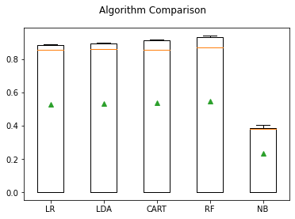

```python
models_performance(models, X_undersampled, y_undersampled)
```

smote sampling

```
LR: 0.768125 (0.114060)
LDA: 0.768652 (0.124790)
CART: 0.781673 (0.156951)
RF: 0.787272 (0.153333)
NB: 0.528212 (0.039300)
```

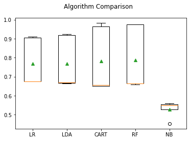

```python
models_performance(models, X_oversampled, y_oversampled)
```

```
Logistic Regression: Train Performance on balanced data
```

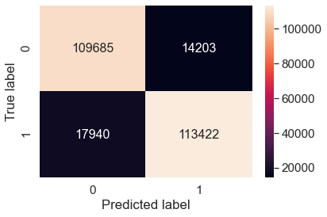

```
Mesurements:
```

|  | F1 | Precision | Recall | AUC | Accuracy |
| --- | --- | --- | --- | --- | --- |
| values | 87.59 | 88.87 | 86.34 | 87.44 | 87.41 |

```python
lr = LogisticRegression().fit(X_oversampled, y_oversampled)

y_pred = lr.predict(X_oversampled)
plot_confusion_matrix(y_pred, y_oversampled, 'Logistic Regression: Train Performance on balanced data')
```

```
Logistic Regression: Test Performance after training on balanced data
```

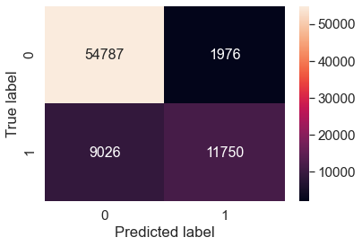

```
Mesurements:
```

|  | F1 | Precision | Recall | AUC | Accuracy |
| --- | --- | --- | --- | --- | --- |
| values | 68.11 | 85.60 | 56.56 | 76.54 | 85.81 |

```python
y_test_pred = lr.predict(X_test)
plot_confusion_matrix(y_test_pred, y_test,
                      'Logistic Regression: Test Performance after training on balanced data')
```

```
regularization: 0.01 f1:  0.764366590590909 std:  0.1132214772216187
regularization: 0.1 f1:  0.7681409699492686 std:  0.11424666632705474
regularization: 1 f1:  0.7685830779331706 std:  0.1147065229751978
regularization: 10 f1:  0.7686166966993528 std:  0.11466515872711594
regularization: 100 f1:  0.7685731212684284 std:  0.11471506133701083
```

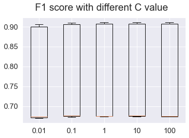

```python
c_scores(X_oversampled, y_oversampled)
```

```
Logistic Regression(C=10,L1): Train Performance on balanced data
```

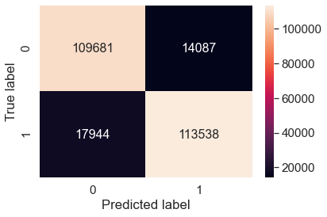

```
Mesurements:
```

|  | F1 | Precision | Recall | AUC | Accuracy |
| --- | --- | --- | --- | --- | --- |
| values | 87.64 | 88.96 | 86.35 | 87.49 | 87.45 |

```python
lr = LogisticRegression(C = 10, penalty='l1',solver='saga').fit(X_oversampled, y_oversampled)

y_pred = lr.predict(X_oversampled)
plot_confusion_matrix(y_pred, y_oversampled,
                      'Logistic Regression(C=10,L1): Train Performance on balanced data')
```

```
Logistic Regression(C=10,L1): Test Performance after training on balanced data
```

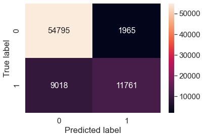

```
Mesurements:
```

|  | F1 | Precision | Recall | AUC | Accuracy |
| --- | --- | --- | --- | --- | --- |
| values | 68.17 | 85.68 | 56.60 | 76.57 | 85.84 |

```python
y_test_pred = lr.predict(X_test)
plot_confusion_matrix(y_test_pred, y_test,
                      'Logistic Regression(C=10,L1): Test Performance after training on balanced data')
```

```
Best threshold based on highest F1 score:
```

|  | Threshold | F1 | Precision | Recall | AUC | Accuracy |
| --- | --- | --- | --- | --- | --- | --- |
| 3 | 0.35 | 0.885247 | 0.833892 | 0.943342 | 0.884337 | 0.877716 |

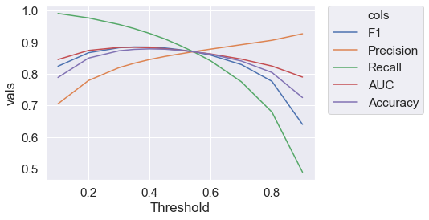

```python
y_pred_proba = lr.predict_proba(X_oversampled)

threshold_range = [0.1, 0.2, 0.3, 0.35, 0.4, 0.45, 0.5, 0.55, 0.6, 0.7, 0.8, 0.9]
best_threshod(y_pred_proba, y_oversampled, threshold_range)
```

```
Logistic Regression(C=10, L1, Threshold=0.35): Train performance on balanced data
```

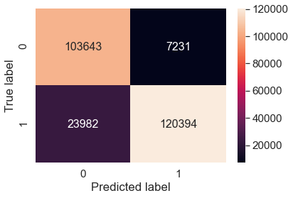

```
Mesurements:
```

|  | F1 | Precision | Recall | AUC | Accuracy |
| --- | --- | --- | --- | --- | --- |
| values | 88.52 | 94.33 | 83.39 | 88.43 | 87.77 |

```python
threshold = 0.35
y_proba = lr.predict_proba(X_oversampled)
y_pred = y_proba[:,1] > threshold

plot_confusion_matrix(y_pred, y_oversampled,
                      'Logistic Regression(C=10, L1, Threshold=0.35): Train performance on balanced data')
```

```
Logistic Regression(C=10, Threshold=0.35): Test Performance after training on balanced data
```

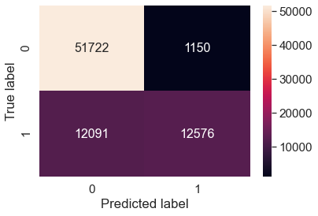

```
Mesurements:
```

|  | F1 | Precision | Recall | AUC | Accuracy |
| --- | --- | --- | --- | --- | --- |
| values | 65.51 | 91.62 | 50.98 | 74.40 | 82.92 |

```python
y_test_proba = lr.predict_proba(X_test)
y_test_pred = y_test_proba[:,1] > 0.35

plot_confusion_matrix(y_test_pred, y_test,
                      'Logistic Regression(C=10, Threshold=0.35): Test Performance after training on balanced data')
```

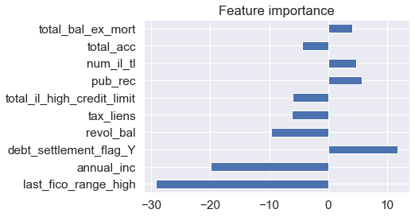

```python
model = LogisticRegression(C = 10, penalty='l1',solver='saga').fit(X_oversampled, y_oversampled)

feat_importances = pd.Series(model.coef_[0], index=X_train.columns)
important = list(feat_importances.abs().nlargest(10).index)
feat_importances[important].plot(kind='barh', title = 'Feature importance')
```